# Data Exploration

Georgia Titcomb

## Look at the data

Here, I have taken the OTU spreadsheet and added the metadata for each sample. The rows are the samples, the columns are the OTUs.

|  | Location | Year | Other | Number | Species | V1 | V2 | V3 | V4 | V5 | V6 | V7 | V8 | V9 | V10 | V11 | V12 | V13 | V14 | V15 | V16 | V17 | V18 | V19 | V20 | V21 | V22 | V23 | V24 | … |
| --- | --- | --- | --- | --- | --- | --- | --- | --- | --- | --- | --- | --- | --- | --- | --- | --- | --- | --- | --- | --- | --- | --- | --- | --- | --- | --- | --- | --- | --- | --- |
| 1 | HIP | 17 |  | 2 | Warthog | 115 | 139 | 21840 | 63 | 114 | 20 | 34 | 23 | 19 | 33 | 5 | 11 | 16 | 9 | 9 | 1 | 3 | 11 | 5 | 5 | 10 | 7 | 6 | 0 | … |
| 2 | HIP | 17 |  | 7 | Elephant | 388 | 71 | 1312 | 13766 | 93 | 13318 | 49 | 216 | 131 | 16 | 69 | 11 | 16 | 56 | 5 | 17 | 3 | 3 | 45 | 1535 | 3 | 7 | 134 | 1 | … |
| 3 | HIP | 17 |  | 9 | Elephant | 188 | 62 | 1729 | 11050 | 76 | 2719 | 29 | 98 | 20 | 18 | 21 | 36 | 4 | 7 | 1 | 0 | 30 | 2 | 15 | 73 | 1 | 6 | 749 | 0 | … |
| 4 | HIP | 17 |  | 13 | Impala | 6262 | 45 | 223 | 665 | 2282 | 484 | 42 | 32 | 4 | 0 | 95 | 1 | 1 | 9 | 1 | 27 | 7 | 2 | 2 | 57 | 2 | 1 | 60 | 0 | … |
| 5 | HIP | 17 |  | 19 | Impala | 14272 | 86 | 174 | 1345 | 184 | 467 | 59 | 96 | 32 | 25 | 85 | 12 | 44 | 8 | 3 | 3 | 1 | 1 | 11 | 11 | 0 | 12 | 19 | 6 | … |
| 6 | HIP | 17 |  | 30 | Plains zebra | 578 | 98 | 81 | 473 | 114 | 296 | 116 | 236 | 4697 | 40 | 57 | 9 | 24 | 40 | 11 | 14 | 3 | 139 | 48 | 35 | 0 | 31 | 36 | 14 | … |

## Investigate specific OTUs

OTU 1 is the most abundant

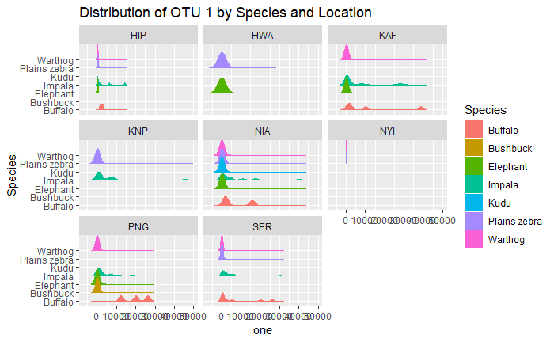

Some observations: Most of the read counts are fairly low, with some that are extremely high, especially for buffalo and impala. Furthermore, I notice a difference among locations: HIP seems to have pretty low counts overall.

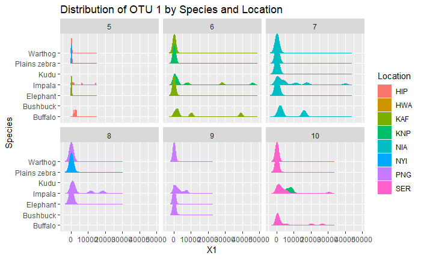

When I separate by plate, I can see that reads seem to be lower on plate 5 than any other plate, across species.

## Normalizing the data

We have a similar problem as before, whereby we need to determine a threshold to determine whether or not a species is present. However, imposing an arbitrary threshold across samples is unlikely to be the best option, as we can see that some plates amplified better than others, and it would make sense that different OTUs and different samples might have different results.

We can rarefy reads within each sample

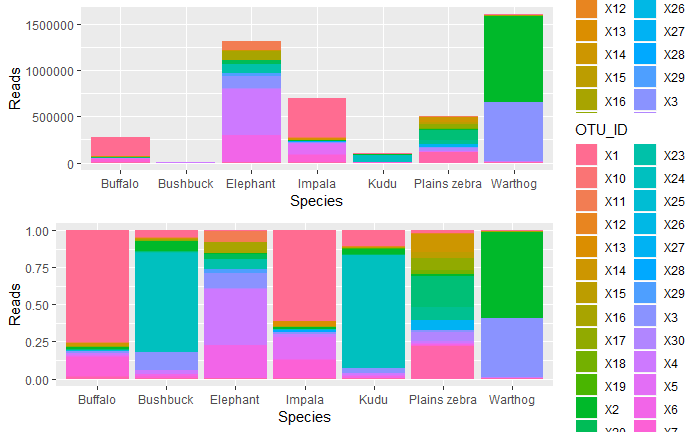

## How many of these OTUs have counts that are useful?

```r
# Which OTUs have a tiny count??
length(which(otutots<10))
```

```
[1] 97
```

There are 97 OTUs that have less than 10 total reads across all samples

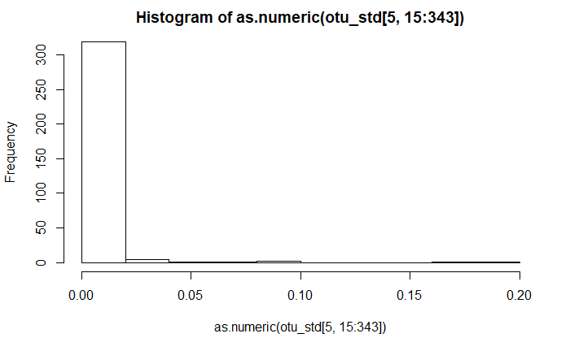

I’m going to use a threshold whereby I discard OTUs that account for less than 5% of reads

|  | Plate | Row | Column | Well | Sample | Forward.Primer | Reverse.Primer | Forward.Tag. | Reverse.Tag. | Tag.Combo | Species | Location | Year | Number | X1 | X2 | X3 | X4 | X5 | X6 | X7 | X9 | X11 | X13 | X14 | X15 | X16 | X17 | X18 | … |
| --- | --- | --- | --- | --- | --- | --- | --- | --- | --- | --- | --- | --- | --- | --- | --- | --- | --- | --- | --- | --- | --- | --- | --- | --- | --- | --- | --- | --- | --- | --- |
| 1 | 5 | B | 1 | B_1 | NYI_17_017 | NC1_F_Tag10 | NC2_R_Tag13 | CCGATGTA | TCATGCGT | CCGATGTA:TCATGCGT | Plains zebra | NYI | 17 | 17 | 0.0000000 | 0 | 0.00000000 | 0.0000000 | 0 | 0.00000000 | 0 | 0.00000000 | 0.00000000 | 0 | 0 | 0 | 0 | 0.1037515 | 0 | … |
| 2 | 5 | C | 1 | C_1 | NYI_17_018 | NC1_F_Tag11 | NC2_R_Tag13 | CTAAGCTC | TCATGCGT | CTAAGCTC:TCATGCGT | Plains zebra | NYI | 17 | 18 | 0.0000000 | 0 | 0.00000000 | 0.0000000 | 0 | 0.00000000 | 0 | 0.00000000 | 0.00000000 | 0 | 0 | 0 | 0 | 0.0000000 | 0 | … |
| 3 | 5 | D | 1 | D_1 | NYI_17_019 | NC1_F_Tag12 | NC2_R_Tag13 | GATGACTC | TCATGCGT | GATGACTC:TCATGCGT | Plains zebra | NYI | 17 | 19 | 0.0000000 | 0 | 0.00000000 | 0.0000000 | 0 | 0.00000000 | 0 | 0.00000000 | 0.00000000 | 0 | 0 | 0 | 0 | 0.8103383 | 0 | … |
| 4 | 5 | C | 2 | C_2 | NYI_17_042 | NC1_F_Tag11 | NC2_R_Tag14 | CTAAGCTC | TCGCATTC | CTAAGCTC:TCGCATTC | Elephant | NYI | 17 | 42 | 0.0000000 | 0 | 0.14593573 | 0.1750473 | 0 | 0.11682420 | 0 | 0.00000000 | 0.16181474 | 0 | 0 | 0 | 0 | 0.0000000 | 0 | … |
| 5 | 5 | A | 3 | A_3 | NYI_17_046 | NC1_F_Tag9 | NC2_R_Tag15 | CTTCTCGA | ATGCCACA | CTTCTCGA:ATGCCACA | Plains zebra | NYI | 17 | 46 | 0.1705628 | 0 | 0.07965368 | 0.1974026 | 0 | 0.08484848 | 0 | 0.00000000 | 0.08571429 | 0 | 0 | 0 | 0 | 0.0000000 | 0 | … |
| 6 | 5 | B | 3 | B_3 | NYI_17_047 | NC1_F_Tag10 | NC2_R_Tag15 | CCGATGTA | ATGCCACA | CCGATGTA:ATGCCACA | Plains zebra | NYI | 17 | 47 | 0.0000000 | 0 | 0.00000000 | 0.0000000 | 0 | 0.00000000 | 0 | 0.09460834 | 0.00000000 | 0 | 0 | 0 | 0 | 0.0000000 | 0 | … |

```r
# Clustering the OTUs and investigating parasite species

hc <- hclust(dist(otu_sparse2[,15:73]))
plot(hc)
cent <- NULL
membs <- cutree(hc, k=10)
for(k in 1:10){
  cent <- rbind(cent, colMeans(otu_sparse2[membs==k,15:73,drop=F]))
}
hcl <- hclust(dist(cent)^2, method="cen", members=table(membs))
opar <- par(mfrow=c(1,2))
plot(hc)
plot(hcl)


kmeans(dist(otu_sparse2[,15:73]), 5)
```

[output not shown]

|  | Species | X1 | X2 | X3 | X4 | X5 | X6 | X7 | X9 | X11 | X13 | X14 | X15 | X16 | X17 | X18 | X20 | X21 | X22 | X23 | X24 | X25 | X27 | X28 | X29 | X30 | X31 | X32 | X33 | … |
| --- | --- | --- | --- | --- | --- | --- | --- | --- | --- | --- | --- | --- | --- | --- | --- | --- | --- | --- | --- | --- | --- | --- | --- | --- | --- | --- | --- | --- | --- | --- |
| 1 | Buffalo | 0.571788012 | 0.0075346923 | 0.009462863 | 0.015599157 | 0.000000000 | 0.005647971 | 0.10333950 | 0.0464750285 | 0.000000000 | 0.00000000 | 0.033963008 | 0.00000000 | 0.00000000 | 0.009255745 | 0.0000000000 | 0.00000000 | 0.001975634 | 0.003447605 | 0.00000000 | 0.0000000 | 0.007456401 | 0.000000000 | 0.000000000 | 0.00000000 | 0.00000000 | 0.00000000 | 0.00000000 | 0.00000000 | … |
| 2 | Bushbuck | 0.038285017 | 0.1174962373 | 0.191688471 | 0.015191796 | 0.000000000 | 0.000000000 | 0.02415254 | 0.0000000000 | 0.000000000 | 0.00000000 | 0.000000000 | 0.00000000 | 0.00000000 | 0.000000000 | 0.0000000000 | 0.00000000 | 0.000000000 | 0.000000000 | 0.00000000 | 0.2572869 | 0.000000000 | 0.000000000 | 0.000000000 | 0.00000000 | 0.00000000 | 0.00000000 | 0.00000000 | 0.00000000 | … |
| 3 | Elephant | 0.000000000 | 0.0007424466 | 0.080100716 | 0.384532458 | 0.000000000 | 0.186805761 | 0.00000000 | 0.0000000000 | 0.072422201 | 0.00000000 | 0.000000000 | 0.00000000 | 0.06357584 | 0.000000000 | 0.0000000000 | 0.02489688 | 0.000000000 | 0.000000000 | 0.03955535 | 0.0000000 | 0.000000000 | 0.000000000 | 0.000000000 | 0.02120373 | 0.00000000 | 0.00000000 | 0.00000000 | 0.02027093 | … |
| 4 | Impala | 0.386201236 | 0.0132316809 | 0.009284514 | 0.013213401 | 0.134864083 | 0.004882631 | 0.08863212 | 0.0005656196 | 0.000000000 | 0.01534803 | 0.004875705 | 0.00000000 | 0.00000000 | 0.000000000 | 0.0005501232 | 0.00000000 | 0.000000000 | 0.000000000 | 0.00000000 | 0.0000000 | 0.000000000 | 0.000761999 | 0.005593498 | 0.00000000 | 0.00000000 | 0.03057875 | 0.00000000 | 0.00000000 | … |
| 5 | Kudu | 0.079993899 | 0.0258669812 | 0.034866487 | 0.000000000 | 0.000000000 | 0.000000000 | 0.00000000 | 0.0000000000 | 0.000000000 | 0.00000000 | 0.000000000 | 0.00000000 | 0.00000000 | 0.000000000 | 0.0000000000 | 0.00000000 | 0.000000000 | 0.000000000 | 0.00000000 | 0.3702579 | 0.000000000 | 0.000000000 | 0.000000000 | 0.00000000 | 0.00000000 | 0.00000000 | 0.00000000 | 0.00000000 | … |
| 6 | Plains zebra | 0.009616549 | 0.0100616034 | 0.001922448 | 0.009836739 | 0.004065193 | 0.004860695 | 0.00000000 | 0.1345404533 | 0.001071429 | 0.00000000 | 0.081197177 | 0.04036898 | 0.00000000 | 0.056579553 | 0.0160264241 | 0.00000000 | 0.084156459 | 0.054599964 | 0.00000000 | 0.0000000 | 0.000000000 | 0.025659396 | 0.000000000 | 0.00000000 | 0.04236432 | 0.00000000 | 0.06348271 | 0.00000000 | … |